```python
import numpy as np
import pandas as pd
from matplotlib import pyplot as plt
import datetime
import seaborn as sn
import math
```

```python
path = 'C:/Users/Utente/Desktop/Carol Alexander/Market_Risk_Analysis_Volume_2/'
```

# Classical Models of Volatility and Correlation

### Variance and Volatility

Volatility is the annualized standard deviation of the returns on an investment. Pitfalls arises when scaling standard deviation into an annualized form. For instance, volatility is much greater when there is positive serial correlation between returns than it is when the returns are i.i.d. The standard deviation of 10-day log returns is not directly comparable with the standard deviation of daily log returns. For this reason we usually transform the standard deviation into annualized terms

$$E(r_{ht}) = hμ $$$$V(r_{ht}) = hσ^2 $$

```python
#example 1
daily_var = 0.001
#a
vol = np.sqrt(daily_var * 250)
print("Annual volatility = " + str(vol))
#b
vol2 = 0.36
print("Weekly std = " + str(vol2 / np.sqrt(52)))
```

```
Annual volatility = 0.5
Weekly std = 0.04992301766027062
```

The assumption that one-period returns are i.i.d. implies that volatility is constant. But it is not realistic to assume that returns are generated by an i.i.d. process. Many models do not make this assumption, including stochastic volatility option pricing models and GARCH statistical models of volatility. Nevertheless the annualization of standard deviation described above has become the market convention for quoting volatility. It is applied to every estimate or forecast of standard deviation, whether or not it is based on an i.i.d. assumption for returns.

$$E(r_{ht}) = hμ $$$$AR(1) Scale Factor = ( h + 2 \dfrac {θ}{(1 - θ)^2} [(h - 1)(1 - θ) - θ(1 - θ^{h-1})])^{1/2} $$

```python
#example 2
monthly_std = 0.05
#(a) if returns are iid
vol_iid =  monthly_std * np.sqrt(12)
#(b) if returns are AR(1)
ar_coeff = 0.25
scale_factor = (12 + 2*(ar_coeff / (1 - ar_coeff)**2)*((12 - 1)*(1 - ar_coeff) - ar_coeff*(1 - pow(ar_coeff,12 - 1))))
vol_ar = monthly_std * np.sqrt(scale_factor)
print("vol_iid = " + str(vol_iid))
print("vol_ar = " + str(vol_ar))
print("the volatility is higher in case of AR(1) compared to the iid assumption")
```

```
vol_iid = 0.17320508075688773
vol_ar = 0.21858128444638747
the volatility is higher in case of AR(1) compared to the iid assumption
```

### Covariance and Correlation

Pearson’s correlation is only appropriate when two returns have an elliptical joint distribution such as the bivariate normal distribution

COVARIANCE MATRIX $$ V = DCD $$ D = diagonal matrix of standard deviations - C = correlation matrix

PORTFOLIO VARIANCE $$ σ_{Port}^2 = w'Vw $$ w = wights vector

```python
#example 3
w = np.array([1/6,2/6,3/6])
asset_vol = np.diag([0.2, 0.1, 0.15])           #diagonal matrix of volatilities
corr_matrix = [[1, 0.8, 0.5], [0.8, 1, 0.3],[0.5, 0.3, 1]]
corr_matrix
```

```
[[1, 0.8, 0.5], [0.8, 1, 0.3], [0.5, 0.3, 1]]
```

```python
covariance_matrix = np.dot(np.dot(asset_vol,corr_matrix), asset_vol) #Excel -> MMULT(MMULT(TRANSPOSE(array1), array2)), array1)
print("Covariance matrix")
covariance_matrix
```

```
Covariance matrix
```

```
array([[0.04  , 0.016 , 0.015 ],
       [0.016 , 0.01  , 0.0045],
       [0.015 , 0.0045, 0.0225]])
```

```python
Portfolio_Variance = np.dot(np.dot(w,covariance_matrix), w.T)
print("Portfolio variance")
Portfolio_Variance
```

```
Portfolio variance
```

```
0.013625
```

scaling covariance matrices.  
Then the variance and covariance scale with time.10 So, to perform an analysis over a risk horizon of h days we can use the square-root-of-time rule to estimate the h-day covariance matrix as hV1, i.e. the matrix where every element of V1 is multiplied by h.

```python
#example 4
#calculate the 10-day covariance matrix from annual volatilities.
h = 250 / 10
scaled_covariance = covariance_matrix / h
print("10-days Scaled Covariance Matrix")
scaled_covariance  #correlation matrix doesn't change, only volatilities do
```

```
10-days Scaled Covariance Matrix
```

```
array([[0.0016 , 0.00064, 0.0006 ],
       [0.00064, 0.0004 , 0.00018],
       [0.0006 , 0.00018, 0.0009 ]])
```

### Equally weighted averages

```python
data = pd.read_excel(path + 'II.3/Examples_II.3.xls', sheet_name = 'EX_II.3.5&8').iloc[:11, :2]
#daily log returns
data['ln_ret'] = np.log(data['FTSE Value'] / data['FTSE Value'].shift())
data.head()
```

|  | Date | FTSE Value | ln_ret |
| --- | --- | --- | --- |
| 0 | 2007-08-10 00:00:00 | 6038.3 | NaN |
| 1 | 2007-08-13 00:00:00 | 6219.0 | 0.029487 |
| 2 | 2007-08-14 00:00:00 | 6143.5 | -0.012215 |
| 3 | 2007-08-15 00:00:00 | 6109.3 | -0.005582 |
| 4 | 2007-08-16 00:00:00 | 5858.9 | -0.041850 |

```python
#if we consider expected returns = 0
data['sqr_ln_ret'] = np.square(data['ln_ret'])
variance_estimate = np.mean(data['sqr_ln_ret'])
volatility_estimate = np.sqrt(variance_estimate * 250)
print('Estimated unconditional volatility with E(return) = 0 is = ' + str(volatility_estimate))
data.head()
```

```
Estimated unconditional volatility with E(return) = 0 is = 0.32897129317823526
```

[output not shown]

```python
#otherwise
ln_ret_mean = np.mean(data['ln_ret'])
data['mean_deviation'] = data['ln_ret'] - ln_ret_mean
data['sqr_mean_deviation'] = np.square(data['mean_deviation'])
variance_estimate = np.sum(data['sqr_mean_deviation']) / (len(data['sqr_mean_deviation']) - 2)  #sample variance
volatility_estimate = np.sqrt(variance_estimate * 250)
print('Estimated unconditional volatility with E(return) != 0 is = ' + str(volatility_estimate))
data.head()
```

```
Estimated unconditional volatility with E(return) != 0 is = 0.3432237824239256
```

|  | Date | FTSE Value | ln_ret | sqr_ln_ret | mean_deviation | sqr_mean_deviation |
| --- | --- | --- | --- | --- | --- | --- |
| 0 | 2007-08-10 00:00:00 | 6038.3 | NaN | NaN | NaN | NaN |
| 1 | 2007-08-13 00:00:00 | 6219.0 | 0.029487 | 0.000869 | 0.026520 | 0.000703 |
| 2 | 2007-08-14 00:00:00 | 6143.5 | -0.012215 | 0.000149 | -0.015181 | 0.000230 |
| 3 | 2007-08-15 00:00:00 | 6109.3 | -0.005582 | 0.000031 | -0.008549 | 0.000073 |
| 4 | 2007-08-16 00:00:00 | 5858.9 | -0.041850 | 0.001751 | -0.044817 | 0.002009 |

just beacuse we use a small sample of recent data, this does not imply that our estimate represents a conditional variance

```python
data2 = pd.read_excel(path + 'II.3/Examples_II.3.xls', sheet_name = 'EX_II.3.7').iloc[:11, :2]
data3 = pd.merge(data, data2, on = 'Date')[['Date', 'FTSE Value', 'SP500 Value']]
data3['ftse_ln_ret'] = np.log(data3['FTSE Value'] / data3['FTSE Value'].shift())
data3['sp500_ln_ret'] = np.log(data3['SP500 Value'].astype('float64') / data3['SP500 Value'].astype('float64').shift())
data3['ftse_sqr_ret'] = np.square(data3['ftse_ln_ret'])
data3['sp500_sqr_ret'] = np.square(data3['sp500_ln_ret'])
data3['cross_product'] = data3['ftse_ln_ret'] * data3['sp500_ln_ret']
data3
```

|  | Date | FTSE Value | SP500 Value | ftse_ln_ret | sp500_ln_ret | ftse_sqr_ret | sp500_sqr_ret | cross_product |
| --- | --- | --- | --- | --- | --- | --- | --- | --- |
| 0 | 2007-08-10 00:00:00 | 6038.3 | 1453.64 | NaN | NaN | NaN | NaN | NaN |
| 1 | 2007-08-13 00:00:00 | 6219.0 | 1452.92 | 0.029487 | -0.000495 | 8.694600e-04 | 2.454519e-07 | -1.460858e-05 |
| 2 | 2007-08-14 00:00:00 | 6143.5 | 1426.54 | -0.012215 | -0.018323 | 1.491942e-04 | 3.357467e-04 | 2.238113e-04 |
| 3 | 2007-08-15 00:00:00 | 6109.3 | 1406.7 | -0.005582 | -0.014005 | 3.116332e-05 | 1.961511e-04 | 7.818389e-05 |
| 4 | 2007-08-16 00:00:00 | 5858.9 | 1411.27 | -0.041850 | 0.003243 | 1.751450e-03 | 1.052011e-05 | -1.357404e-04 |
| 5 | 2007-08-17 00:00:00 | 6064.2 | 1445.94 | 0.034441 | 0.024270 | 1.186166e-03 | 5.890145e-04 | 8.358641e-04 |
| 6 | 2007-08-20 00:00:00 | 6078.7 | 1445.55 | 0.002388 | -0.000270 | 5.703633e-06 | 7.276890e-08 | -6.442415e-07 |
| 7 | 2007-08-21 00:00:00 | 6086.1 | 1447.12 | 0.001217 | 0.001086 | 1.480177e-06 | 1.178316e-06 | 1.320650e-06 |
| 8 | 2007-08-22 00:00:00 | 6196.0 | 1464.07 | 0.017896 | 0.011645 | 3.202826e-04 | 1.356026e-04 | 2.084014e-04 |
| 9 | 2007-08-23 00:00:00 | 6196.9 | 1462.5 | 0.000145 | -0.001073 | 2.109595e-08 | 1.151176e-06 | -1.558369e-07 |
| 10 | 2007-08-24 00:00:00 | 6220.1 | 1479.37 | 0.003737 | 0.011469 | 1.396380e-05 | 1.315385e-04 | 4.285763e-05 |

In the equally weighted model the covariance matrix forecast and hence also the associated forecasts of volatilities and correlations are assumed to be equal to their estimates. This is the only possibility in the context of an equally weighted model, which assumes returns are i.i.d. Since the volatility and correlation parameters are constant over time, there is nothing in the model to distinguish an estimate from a forecast. It is usual to take the horizon for the forecast to be determined by the frequency of the data used to estimate the volatilities and correlations.

### CASE STUDY : Volatily and Correlation of US Treasury

```
US Treasury rates between 4 Jan 1982 and 27 Aug 2007
                        m3     m6     y1     y2     y3     y5    y10
Date
1982-04-01 00:00:00  11.87  13.16  13.56  13.87  14.06  14.15  14.19
1982-05-01 00:00:00  12.20  13.41  13.83  14.09  14.34  14.41  14.44
1982-06-01 00:00:00  12.16  13.46  13.91  14.19  14.41  14.60  14.59
1982-07-01 00:00:00  12.17  13.43  13.93  14.33  14.48  14.66  14.63
1982-08-01 00:00:00  11.98  13.35  13.75  14.11  14.33  14.47  14.48
```

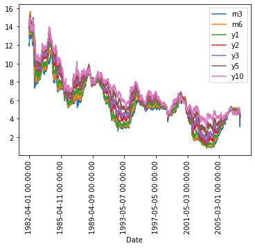

```python
df = pd.read_excel(path + 'II.3/Case Study_II.3.xls', sheet_name = 'Data').set_index('Date')
print("US Treasury rates between 4 Jan 1982 and 27 Aug 2007")
print(df.head())
df.plot()
plt.xticks(rotation=90)
```

```python
df.index=pd.to_datetime(df.index)
```

Since interest rate sensitivities are usually measured in basis points, the volatilities in an interest rate covariance matrix are usually also expressed in basis points

```python
#calulate returns in basis points
df2 = df.diff()*100
df2.head()
```

| Date | m3 | m6 | y1 | y2 | y3 | y5 | y10 |
| --- | --- | --- | --- | --- | --- | --- | --- |
| 1982-04-01 | NaN | NaN | NaN | NaN | NaN | NaN | NaN |
| 1982-05-01 | 33.0 | 25.0 | 27.0 | 22.0 | 28.0 | 26.0 | 25.0 |
| 1982-06-01 | -4.0 | 5.0 | 8.0 | 10.0 | 7.0 | 19.0 | 15.0 |
| 1982-07-01 | 1.0 | -3.0 | 2.0 | 14.0 | 7.0 | 6.0 | 4.0 |
| 1982-08-01 | -19.0 | -8.0 | -18.0 | -22.0 | -15.0 | -19.0 | -15.0 |

```python
#period 1
start1 = datetime.datetime(1991, 1, 1, 0, 0)
end1 = datetime.datetime(1995, 12, 31, 0, 0)
per1 = df2.loc[(df2.index > start1) & (df2.index < end1)]

#period 2
start2 = datetime.datetime(1996, 1, 1, 0, 0)
end2 = datetime.datetime(2001, 12, 31, 0, 0)
per2 = df2.loc[(df2.index > start2) & (df2.index < end2)]

#period 1
start3 = datetime.datetime(2001, 1, 1, 0, 0)
end3 = datetime.datetime(2005, 12, 31, 0, 0)
per3 = df2.loc[(df2.index > start3) & (df2.index < end3)]
```

```python
#Period 1
vol1 = np.std(per1)*np.sqrt(250)
corr1 = per1.corr()
print("Volatilities period 1 : \n" + str(vol1))
print("*"*50)
print("Correlaiton period 1 : ")
print(corr1)
print("*"*50)

#Period 2
vol2 = np.std(per2)*np.sqrt(250)
corr2 = per2.corr()
print("Volatilities period 2 : \n" + str(vol2))
print("*"*50)
print("Correlaiton period 2 : ")
print(corr2)
print("*"*50)

#Period 3
vol3 = np.std(per3)*np.sqrt(250)
corr3 = per3.corr()
print("Volatilities period 3 : \n" + str(vol3))
print("*"*50)
print("Correlaiton period 3 : ")
print(corr3)
print("*"*50)
```

```
Volatilities period 1 :
m3     73.152658
m6     74.347150
y1     86.264419
y2     97.066742
y3     98.255626
y5     98.639441
y10    89.081647
dtype: float64
Correlaiton period 1 :
           m3        m6        y1        y2        y3        y5       y10
m3   1.000000  0.868563  0.717045  0.626604  0.586213  0.542724  0.451935
m6   0.868563  1.000000  0.867298  0.796143  0.761423  0.717129  0.620503
y1   0.717045  0.867298  1.000000  0.911073  0.888045  0.846035  0.744745
y2   0.626604  0.796143  0.911073  1.000000  0.947510  0.922116  0.829450
y3   0.586213  0.761423  0.888045  0.947510  1.000000  0.959456  0.890514
y5   0.542724  0.717129  0.846035  0.922116  0.959456  1.000000  0.941399
y10  0.451935  0.620503  0.744745  0.829450  0.890514  0.941399  1.000000
Volatilities period 2 :
m3     86.975459
m6     73.630585
y1     78.176021
y2     92.836371
y3     95.820958
y5     96.350102
y10    92.125909
dtype: float64
Correlaiton period 2 :
           m3        m6        y1        y2        y3        y5       y10
m3   1.000000  0.738868  0.566281  0.439212  0.403608  0.361961  0.294863
m6   0.738868  1.000000  0.797592  0.695146  0.651015  0.605951  0.523558
y1   0.566281  0.797592  1.000000  0.893111  0.864324  0.820443  0.738792
y2   0.439212  0.695146  0.893111  1.000000  0.965329  0.925561  0.854204
y3   0.403608  0.651015  0.864324  0.965329  1.000000  0.956234  0.892392
y5   0.361961  0.605951  0.820443  0.925561  0.956234  1.000000  0.943528
y10  0.294863  0.523558  0.738792  0.854204  0.892392  0.943528  1.000000
Volatilities period 3 :
m3      59.602759
m6      59.585978
y1      75.434306
y2     102.838589
y3     108.270192
y5     107.343246
y10     97.316071
dtype: float64
Correlaiton period 3 :
           m3        m6        y1        y2        y3        y5       y10
m3   1.000000  0.813404  0.637633  0.478540  0.442622  0.394768  0.312227
m6   0.813404  1.000000  0.864266  0.698196  0.653620  0.595364  0.502483
y1   0.637633  0.864266  1.000000  0.875596  0.834558  0.781218  0.697418
y2   0.478540  0.698196  0.875596  1.000000  0.972183  0.919905  0.843080
y3   0.442622  0.653620  0.834558  0.972183  1.000000  0.955561  0.889424
y5   0.394768  0.595364  0.781218  0.919905  0.955561  1.000000  0.953222
y10  0.312227  0.502483  0.697418  0.843080  0.889424  0.953222  1.000000
```

```python
mat_int_rates = pd.DataFrame([vol1, vol2, vol3]).T
mat_int_rates.columns = ['Period1', 'Period2', 'Period3']
mat_int_rates
```

|  | Period1 | Period2 | Period3 |
| --- | --- | --- | --- |
| m3 | 73.152658 | 86.975459 | 59.602759 |
| m6 | 74.347150 | 73.630585 | 59.585978 |
| y1 | 86.264419 | 78.176021 | 75.434306 |
| y2 | 97.066742 | 92.836371 | 102.838589 |
| y3 | 98.255626 | 95.820958 | 108.270192 |
| y5 | 98.639441 | 96.350102 | 107.343246 |
| y10 | 89.081647 | 92.125909 | 97.316071 |

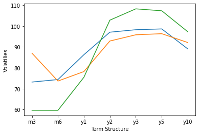

```python
plt.plot(mat_int_rates)
plt.xlabel("Term Structure")
plt.ylabel("Volatilies")
plt.show()
```

```python
#should we chose to apply volatilities and correlation to absolute or relative changes ?

#period 4
start4 = datetime.datetime(2006, 1, 1, 0, 0)
end4 = datetime.datetime(2007, 8, 27, 0, 0)
per4 = df.loc[(df.index > start4) & (df.index < end4)]
per4
```

| Date | m3 | m6 | y1 | y2 | y3 | y5 | y10 |
| --- | --- | --- | --- | --- | --- | --- | --- |
| 2006-03-01 | 4.16 | 4.40 | 4.38 | 4.34 | 4.30 | 4.30 | 4.37 |
| 2006-04-01 | 4.19 | 4.37 | 4.35 | 4.31 | 4.28 | 4.28 | 4.36 |
| 2006-05-01 | 4.20 | 4.37 | 4.36 | 4.32 | 4.29 | 4.29 | 4.36 |
| 2006-06-01 | 4.22 | 4.39 | 4.38 | 4.36 | 4.32 | 4.32 | 4.38 |
| 2006-09-01 | 4.23 | 4.40 | 4.39 | 4.36 | 4.32 | 4.32 | 4.38 |
| ... | ... | ... | ... | ... | ... | ... | ... |
| 2007-08-20 | 3.12 | 4.17 | 4.15 | 4.11 | 4.19 | 4.32 | 4.64 |
| 2007-08-21 | 3.59 | 4.08 | 4.07 | 4.05 | 4.12 | 4.27 | 4.60 |
| 2007-08-22 | 3.67 | 4.08 | 4.10 | 4.15 | 4.19 | 4.34 | 4.63 |
| 2007-08-23 | 3.89 | 4.19 | 4.19 | 4.20 | 4.24 | 4.36 | 4.62 |
| 2007-08-24 | 4.24 | 4.32 | 4.31 | 4.30 | 4.31 | 4.42 | 4.63 |

386 rows × 7 columns

```python
per4_diff = per4.diff()*100
vol4_diff = np.std(per4_diff)*np.sqrt(250)
corr4_diff = per4_diff.corr()
print("Volatilities period 4 : \n" + str(vol4_diff))
print("*"*50)
print("Correlaiton period 4 : ")
corr4_diff
```

```
Volatilities period 4 :
m3     99.190993
m6     56.129684
y1     55.903864
y2     73.669843
y3     73.250138
y5     71.257836
y10    63.431342
dtype: float64
Correlaiton period 4 :
```

|  | m3 | m6 | y1 | y2 | y3 | y5 | y10 |
| --- | --- | --- | --- | --- | --- | --- | --- |
| m3 | 1.000000 | 0.578276 | 0.521590 | 0.311647 | 0.271151 | 0.241504 | 0.161977 |
| m6 | 0.578276 | 1.000000 | 0.924786 | 0.606614 | 0.584363 | 0.549922 | 0.449306 |
| y1 | 0.521590 | 0.924786 | 1.000000 | 0.842417 | 0.817129 | 0.785401 | 0.684036 |
| y2 | 0.311647 | 0.606614 | 0.842417 | 1.000000 | 0.961694 | 0.944066 | 0.869780 |
| y3 | 0.271151 | 0.584363 | 0.817129 | 0.961694 | 1.000000 | 0.972471 | 0.918040 |
| y5 | 0.241504 | 0.549922 | 0.785401 | 0.944066 | 0.972471 | 1.000000 | 0.950784 |
| y10 | 0.161977 | 0.449306 | 0.684036 | 0.869780 | 0.918040 | 0.950784 | 1.000000 |

```python
per4_ln = np.log(per4/per4.shift())
per4_ln.head()
```

| Date | m3 | m6 | y1 | y2 | y3 | y5 | y10 |
| --- | --- | --- | --- | --- | --- | --- | --- |
| 2006-03-01 | NaN | NaN | NaN | NaN | NaN | NaN | NaN |
| 2006-04-01 | 0.007186 | -0.006842 | -0.006873 | -0.006936 | -0.004662 | -0.004662 | -0.002291 |
| 2006-05-01 | 0.002384 | 0.000000 | 0.002296 | 0.002317 | 0.002334 | 0.002334 | 0.000000 |
| 2006-06-01 | 0.004751 | 0.004566 | 0.004577 | 0.009217 | 0.006969 | 0.006969 | 0.004577 |
| 2006-09-01 | 0.002367 | 0.002275 | 0.002281 | 0.000000 | 0.000000 | 0.000000 | 0.000000 |

```python
vol4_ln = np.std(per4_ln)*np.sqrt(250)
corr4_ln = per4_ln.corr()
print("Volatilities period 4 : \n" + str(vol4_ln))
print("*"*50)
print("Correlaiton period 4 : ")
corr4_ln
```

```
Volatilities period 4 :
m3     0.256188
m6     0.118511
y1     0.118052
y2     0.157365
y3     0.156663
y5     0.151470
y10    0.132026
dtype: float64
Correlaiton period 4 :
```

|  | m3 | m6 | y1 | y2 | y3 | y5 | y10 |
| --- | --- | --- | --- | --- | --- | --- | --- |
| m3 | 1.000000 | 0.505417 | 0.468520 | 0.294558 | 0.249493 | 0.217012 | 0.141821 |
| m6 | 0.505417 | 1.000000 | 0.929030 | 0.607806 | 0.582199 | 0.545136 | 0.435822 |
| y1 | 0.468520 | 0.929030 | 1.000000 | 0.838631 | 0.811731 | 0.778039 | 0.668477 |
| y2 | 0.294558 | 0.607806 | 0.838631 | 1.000000 | 0.962739 | 0.944196 | 0.864519 |
| y3 | 0.249493 | 0.582199 | 0.811731 | 0.962739 | 1.000000 | 0.972342 | 0.913869 |
| y5 | 0.217012 | 0.545136 | 0.778039 | 0.944196 | 0.972342 | 1.000000 | 0.948584 |
| y10 | 0.141821 | 0.435822 | 0.668477 | 0.864519 | 0.913869 | 0.948584 | 1.000000 |

### Equally Weighted Moving Averages

```
            MIB30    SP500
Date
2000-01-03  41477  1455.22
2000-01-04  40468  1399.42
2000-01-05  39449  1402.11
2000-01-06  38736  1403.45
2000-01-07  40199  1441.47
```

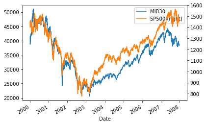

```python
df_ma = pd.read_excel(path + 'II.3/Examples_II.3.xls', sheet_name = 'EX_II.3.12').set_index('Date')[['MIB30', 'SP500']]
print(df_ma.head())
df_ma.plot(secondary_y = "SP500")
plt.xticks(rotation=90)
```

```
               MIB30     SP500  30_day_vol_MIB  60_day_vol_MIB  \
Date
2007-12-19 -0.005911 -0.001362        0.010836        0.009344
2007-12-20 -0.002694  0.004888        0.010836        0.009244
2007-12-21  0.008838  0.016532        0.010425        0.009331
2007-12-27  0.004351 -0.005532        0.009871        0.009341
2007-12-28  0.004924  0.001503        0.009853        0.009203

            90_day_vol_MIB  30_day_vol_SP  60_day_vol_SP  90_day_vol_SP
Date
2007-12-19        0.010777       0.014904       0.012426       0.012355
2007-12-20        0.010748       0.013947       0.012422       0.012209
2007-12-21        0.010102       0.014284       0.012608       0.012233
2007-12-27        0.009911       0.014061       0.012620       0.012246
2007-12-28        0.009907       0.013919       0.012494       0.011982
```

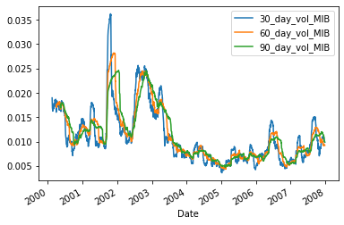

```python
df_ma2 = np.log(df_ma/df_ma.shift())


df_ma2['30_day_vol_MIB'] = df_ma2['MIB30'].rolling(30).std()
df_ma2['60_day_vol_MIB'] = df_ma2['MIB30'].rolling(60).std()
df_ma2['90_day_vol_MIB'] = df_ma2['MIB30'].rolling(90).std()

df_ma2['30_day_vol_SP'] = df_ma2['SP500'].rolling(30).std()
df_ma2['60_day_vol_SP'] = df_ma2['SP500'].rolling(60).std()
df_ma2['90_day_vol_SP'] = df_ma2['SP500'].rolling(90).std()

print(df_ma2.tail())
df_ma2[['30_day_vol_MIB', '60_day_vol_MIB', '90_day_vol_MIB']].plot()
```

### Exponentially weighted moving averages

$$ EWMA(X_{t-1}, ...., X_{1} | λ ) = \frac{X_{t-1} + λX_{t-2} + λ^2X_{t-3} + ... + λ^{t-2}X_{1}}{1 + λ + λ^2 + ... + λ^{t -2}} $$

where λ is a smoothing constant (decay parameter) 0 < λ < 1

Here variance and convariances may calulcated in form of recursion VARIANCE : $$ \hat{σ}_{t}^2 = (1 - λ)r_{t-1}^2 + λ\hat{σ}_{t-1}^2 $$ $(1 - λ)r_{t-1}^2$= intensity in reaction $λ\hat{σ}_{t-1}^2$= persistence in volatility

COVARIANCE: $$ \hat{σ}_{12,t}^2 = (1 - λ)r_{1,t-1}r_{2,t-1} + λ\hat{σ}_{12,t-1}^2 $$

a high λ gives little reaction to actual market events but great persistence in volatility; a low λ gives highly reactive volatilities that quickly die away How do we choose λ? It can be chosen to minimize the root mean sqaure error between the EWMA estimated of variance and squared returns

# Time series model and cointegration

cointegration models are constructed in two stages:

- the first stage examines the association in a long term equilibrium between the prices of a set of financial assets
- the second stage is a dynamic model of correlation, called an error correction model, that is based on linear regression analysis of returns

The presence of cointegration also implies that there is a statistical causality between the returns. The returns on one asset tend to lag the returns on the other, so that large price changes in one asset tend to be followed, at some time in the future, by large price changes in the other. This type of statistical causality is called Granger causality  
Cointegration has emerged as a powerful technique for investigating long term dependence in multivariate time series, not just between two asset prices or interest rates. The main advantage of cointegration is that it provides a sound statistical methodology for modelling both the long term equilibrium and the short term dynamics.

### Stationary processes

A descrete stochastic process is stationary if:

- $ E(X_{t}) $ is a finite constant
- $ V(X_{t}) $ is a finite constant
- the joint distribution of $ (X_{t}, X_{s}) $ depends om t - s

In case of weakly stationarity $COV(X_{t}, X_{s}) $ depends only on $ \lvert t - s \rvert $

pth order autogression model $$ X_{t} = α + Q_{1}X_{t-1} + Q_{2}X_{t-2} + ... + Q_{p}X_{t-p} + ε_{t}, \quad ε_{t} \sim i.i.d(0, σ^2) $$ Moving Average Model MA(1) $$ X_{t} = ε_{t} + φε_{t-1}, \quad ε_{t} \sim i.i.d(0, σ^2) $$ ARMA(p,q) $$ X_{t} = α + Q_{1}X_{t-1} + Q_{2}X_{t-2} + ... + Q_{p}X_{t-p} + ε_{t} + φ_{1}ε_{t-1} + ... + φ_{q}ε_{t-q}, \quad ε_{t} \sim i.i.d(0, σ^2) $$

```
            Spread  Lag 1  Lag 2  Lag 3
Date
2005-09-22   110.0   95.0  150.0  148.0
2005-09-23   125.0  110.0   95.0  150.0
2005-09-26   207.0  125.0  110.0   95.0
2005-09-27   162.0  207.0  125.0  110.0
2005-09-28   213.0  162.0  207.0  125.0
```

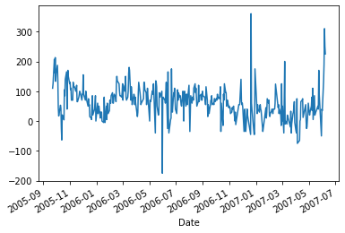

```python
#example 3
df = pd.read_excel(path + 'II.5\Examples_II.5.xls', sheet_name = 'EX_II.5.3').set_index('Date').iloc[:, :4]
print(df.head())
df.Spread.plot()
```

```
Autocorrelations:
[1.         0.40033936 0.29637816 0.21524884 0.17829839 0.22541079
 0.09129837 0.14399961 0.08804386 0.10141323 0.12411168 0.09564334
 0.11922767 0.09194118 0.12500858 0.08363148 0.0824933  0.13282406
 0.08717355 0.11991728 0.13787561 0.13450149 0.10635261 0.06261052
 0.06529906 0.04802203 0.03522806 0.05593172 0.016391   0.0224103
 0.0136735 ]

To determine the order of an ARMA process we examine the sample correlogram.
```

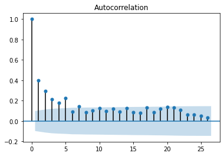

```python
from statsmodels.graphics.tsaplots import plot_acf, acf
nlags = 30
X_acf = acf(df.Spread, nlags=nlags)
print ('Autocorrelations:\n' + str(X_acf) + '\n')
plot_acf(df.Spread)
print("To determine the order of an ARMA process we examine the sample correlogram.")
```

AR(2) or ARMA(2,1) model may be appropriate  
We estimate the parameters of ARMA models using maximum likelihood estimation (MLE) because these estimators are consistent under fairly general conditions. When the disturbance term t is normally distributed MLE is equivalent to ordinary least squares (OLS) and for simplicity we shall make that assumption here

```python
import statsmodels.api as sm
# split features and target
X = df[["Lag 1", "Lag 2"]]
y = df.Spread
# fit model and summarize
sm.OLS(y,X).fit().summary()
```

OLS Regression Results

| Dep. Variable: | Spread | R-squared (uncentered): | 0.611 |
| --- | --- | --- | --- |
| Model: | OLS | Adj. R-squared (uncentered): | 0.609 |
| Method: | Least Squares | F-statistic: | 310.6 |
| Date: | Sun, 22 Nov 2020 | Prob (F-statistic): | 7.49e-82 |
| Time: | 11:03:23 | Log-Likelihood: | -2146.2 |
| No. Observations: | 398 | AIC: | 4296. |
| Df Residuals: | 396 | BIC: | 4304. |
| Df Model: | 2 |  |  |
| Covariance Type: | nonrobust |  |  |

|  | coef | std err | t | P>\|t\| | [0.025 | 0.975] |
| --- | --- | --- | --- | --- | --- | --- |
| Lag 1 | 0.4996 | 0.047 | 10.572 | 0.000 | 0.407 | 0.593 |
| Lag 2 | 0.3436 | 0.048 | 7.219 | 0.000 | 0.250 | 0.437 |

| Omnibus: | 97.812 | Durbin-Watson: | 2.140 |
| --- | --- | --- | --- |
| Prob(Omnibus): | 0.000 | Jarque-Bera (JB): | 1175.888 |
| Skew: | 0.648 | Prob(JB): | 4.56e-256 |
| Kurtosis: | 11.320 | Cond. No. | 2.61 |

Warnings:  
[1] Standard Errors assume that the covariance matrix of the errors is correctly specified.

### Stochastic trend

Random Walk: $$ X_{t} = X_{t-1} + ε_{t}, \quad ε_{t} \sim i.i.d(0, σ^2) $$ Random walk with drift: $$ X_{t} = α + X_{t-1} + ε_{t} $$

the random walk has infinite unconditional mean and variance. Since X t−1 is known and therefore not random at time t, the conditional mean and conditional variance, i.e. the mean and variance taken at every step in the random walk, are finite and are given by; $$ E_{t-1}(X_{t-1}) = α + X_{t-1} \quad and \quad V_{t-1}(X_{t}) = σ^2 $$

A time series process is said to be integrated of order i and denoted I(1) if it is not stationary but its first difference has a stationary ARMA representation. Hence, the random walk model is just one particular type of integrated process, one in which the first difference is i.i.d. More generally, the first difference of an integrated process can have autocorrelated and moving average components. It just needs to be stationary. $$ X_{t} \sim I(1) \Leftrightarrow X_{t} = α + X_{t-1} + ε_{t} \quad with \quad ε_{t} \sim I(0) $$

we use the notation I(0) as before to denote that a series is stationary.  
When a process is integrated of order 1 we say that it has a stochastic trend. For instance, the random walk model has a stochastic trend as well as a drift determined by the sign and magnitude of the constant α.

UNIT ROOTS TEST:  
Statistical tests of the null hypothesis that a time series is non-stationary versus the alternative that it is stationary are called unit root tests. The name derives from the fact that an autoregressive process is stationary if and only if the roots of its characteristic polynomial lie strictly inside the unit circle

```python
from statsmodels.tsa.stattools import adfuller
df2 = pd.read_excel(path + 'II.5/Examples_II.5.xls', sheet_name = 'EX_II.5.5').set_index('Date')[['FTSE 100', 'S&P 500 ', 'FX ($/£)']]
df2.head()
```

| Date | FTSE 100 | S&P 500 | FX ($/£) |
| --- | --- | --- | --- |
| 1996-01-02 | 3687.9 | 620.73 | 0.642467 |
| 1996-01-03 | 3715.6 | 621.32 | 0.644454 |
| 1996-01-04 | 3714.1 | 617.70 | 0.646705 |
| 1996-01-05 | 3704.5 | 616.71 | 0.644330 |
| 1996-01-08 | 3720.6 | 618.46 | 0.645369 |

```python
df2_ln = np.log(df2)
print(df2_ln.head())
print('-'*50)
result = adfuller(df2_ln['FTSE 100'])
print('ADF Statistic: {}'.format(result[0]))
print('p-value: {}'.format(result[1]))
print('Critical Values:')
for key, value in result[4].items():
    print('\t{}: {}'.format(key, value))
```

```
            FTSE 100  S&P 500   FX ($/£)
Date
1996-01-02  8.212812  6.430896 -0.442440
1996-01-03  8.220295  6.431846 -0.439351
1996-01-04  8.219892  6.426003 -0.435865
1996-01-05  8.217304  6.424399 -0.439544
1996-01-08  8.221640  6.427233 -0.437932
--------------------------------------------------
ADF Statistic: -1.766637298053028
p-value: 0.39714656875977894
Critical Values:
	1%: -3.4327484835605944
	5%: -2.862599676387103
	10%: -2.567334100151985
```

```python
df2_ln_ret = (df2_ln / df2_ln.shift())[1:]
print(df2_ln_ret.head())
print('-'*50)
result = adfuller(df2_ln_ret['FTSE 100'])
print('ADF Statistic: {}'.format(result[0]))
print('p-value: {}'.format(result[1]))
print('Critical Values:')
for key, value in result[4].items():
    print('\t{}: {}'.format(key, value))
```

```
            FTSE 100  S&P 500   FX ($/£)
Date
1996-01-03  1.000911  1.000148  0.993019
1996-01-04  0.999951  0.999091  0.992065
1996-01-05  0.999685  0.999750  1.008442
1996-01-08  1.000528  1.000441  0.996332
1996-01-09  1.000000  0.997717  0.997051
--------------------------------------------------
ADF Statistic: -17.87464603458196
p-value: 3.018401742637035e-30
Critical Values:
	1%: -3.432752007595283
	5%: -2.86260123271692
	10%: -2.5673349287433718
```

### Autoregressive models

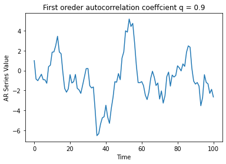

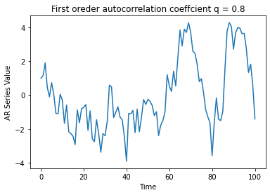

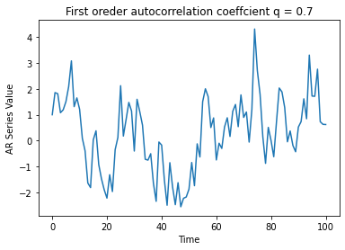

```python
from scipy import stats

# ensures experiment runs the same every time
np.random.seed(100)

# This function simluates an AR process, generating a new value based on historial values,
# autoregressive coefficients b1 ... bk, and some randomness.
def AR(b, X, mu, sigma):
    l = min(len(b)-1, len(X))
    b0 = b[0]

    return b0 + np.dot(b[1:l+1], X[-l:]) + np.random.normal(mu, sigma)

q1 = np.array([0, 0.9])
X1 = np.array([1])

q2 = np.array([0, 0.8])
X2 = np.array([1])

q3 = np.array([0, 0.7])
X3 = np.array([1])

mu = 0
sigma = 1

for i in range(100):
    X1 = np.append(X1, AR(q1, X1, mu, sigma))
    X2 = np.append(X2, AR(q2, X2, mu, sigma))
    X3 = np.append(X3, AR(q3, X3, mu, sigma))

plt.plot(X1)
plt.title('First oreder autocorrelation coeffcient q = 0.9')
plt.xlabel('Time')
plt.ylabel('AR Series Value');
plt.show()

plt.plot(X2)
plt.title('First oreder autocorrelation coeffcient q = 0.8')
plt.xlabel('Time')
plt.ylabel('AR Series Value');
plt.show()

plt.plot(X3)
plt.title('First oreder autocorrelation coeffcient q = 0.7')
plt.xlabel('Time')
plt.ylabel('AR Series Value');
plt.show()
```

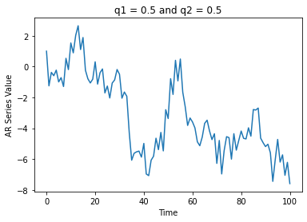

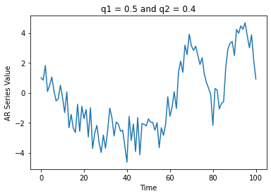

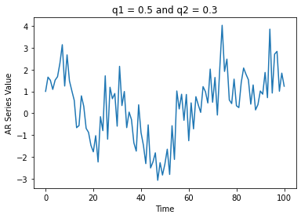

```python
from scipy import stats

# ensures experiment runs the same every time
np.random.seed(100)

# This function simluates an AR process, generating a new value based on historial values,
# autoregressive coefficients b1 ... bk, and some randomness.
def AR(b, X, mu, sigma):
    l = min(len(b)-1, len(X))
    b0 = b[0]

    return b0 + np.dot(b[1:l+1], X[-l:]) + np.random.normal(mu, sigma)

q1 = np.array([0, 0.5, 0.5])
X1 = np.array([1])


q2 = np.array([0, 0.5, 0.4])
X2 = np.array([1])

q3 = np.array([0, 0.5, 0.3])
X3 = np.array([1])

mu = 0
sigma = 1

for i in range(100):
    X1 = np.append(X1, AR(q1, X1, mu, sigma))
    X2 = np.append(X2, AR(q2, X2, mu, sigma))
    X3 = np.append(X3, AR(q3, X3, mu, sigma))

plt.plot(X1)
plt.title('q1 = 0.5 and q2 = 0.5')
plt.xlabel('Time')
plt.ylabel('AR Series Value');
plt.show()

plt.plot(X2)
plt.title('q1 = 0.5 and q2 = 0.4')
plt.xlabel('Time')
plt.ylabel('AR Series Value');
plt.show()

plt.plot(X3)
plt.title('q1 = 0.5 and q2 = 0.3')

plt.xlabel('Time')
plt.ylabel('AR Series Value');
plt.show()
```

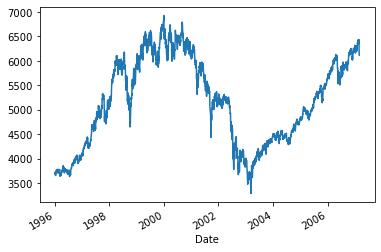

```python
# Example FTSE 100
ts = pd.read_excel(path + 'II.5/Examples_II.5.xls', sheet_name = 'EX_II.5.5').set_index('Date')['FTSE 100']
ts.plot()
```

```
ADF Statistic: -24.081367907585577
p-value: 0.0
```

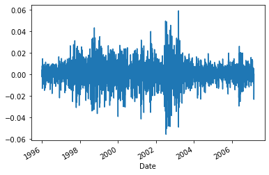

```python
#returns
ts_ln_ret = np.log(ts / ts.shift())[1:]
result = adfuller(ts_ln_ret)
print('ADF Statistic: {}'.format(result[0]))
print('p-value: {}'.format(result[1]))
ts_ln_ret.plot()
```

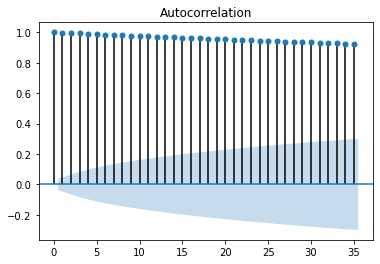

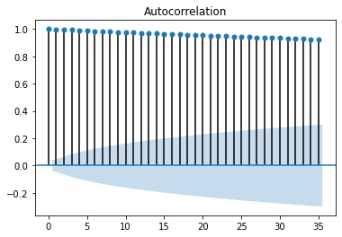

```python
plot_acf(ts)
```

```python
ts.size
```

```
2736
```

```python
X = ts.values
train = X[0:2700] # 27 data as train data
test = X[2700:]  # 9 data as test data
predictions = []
```

```python
from statsmodels.tsa.ar_model import AR
from sklearn.metrics import mean_squared_error
model_ar = AR(train)
model_ar_fit = model_ar.fit()

predictions = model_ar_fit.predict(start=2700,end=2736)
predictions
```

```
array([6201.01857189, 6194.17873833, 6189.90628678, 6195.27580749,
       6199.62397606, 6192.821077  , 6190.09766721, 6196.30050965,
       6193.09879318, 6188.6776795 , 6191.01299679, 6191.18243344,
       6189.92623537, 6186.77705713, 6184.74326654, 6186.36301469,
       6183.93538697, 6182.0797033 , 6187.92469991, 6186.33228148,
       6185.53979254, 6186.88505389, 6185.56351017, 6182.84473977,
       6180.57465888, 6180.03095287, 6179.8419525 , 6179.09709587,
       6177.74611218, 6177.36768297, 6177.41281085, 6176.03242395,
       6175.01874826, 6174.83238438, 6173.92930708, 6172.92150123,
       6172.16226001])
```

We will use information criterion, specifically Akaike Information Criterion (AIC) and Bayes Information Criterion (BIC) to decide the correct number of parameters. Compute the AIC and BIC for all models we wish to consider, and note the smallest AIC and BIC recorded AICmin and BICmin . These are the models which minimize information loss under each metric.

```python
#check best parameters to fit the model
import itertools
from statsmodels.tsa.arima_model import ARIMA
p=d=q=range(0,3)
pdq = list(itertools.product(p,d,q))
pdq

import warnings
warnings.filterwarnings('ignore')
for param in pdq:
    try:
        model_arima = ARIMA(train,order=param)
        model_arima_fit = model_arima.fit()
        print(param,model_arima_fit.aic)
    except:
        continue
```

```
(0, 0, 0) 44318.27055561665
(0, 0, 1) 40800.056262720274
(0, 1, 0) 29494.913647258905
(0, 1, 1) 29496.206387512415
(0, 1, 2) 29484.31307207756
(0, 2, 0) 31314.298185843636
(0, 2, 1) 29494.830936339775
(0, 2, 2) 29496.090780263552
(1, 0, 0) 29512.201382769705
(1, 0, 1) 29513.372290375333
(1, 0, 2) 29502.656465943335
(1, 1, 0) 29496.309097024554
(1, 1, 1) 29495.91215107818
(1, 1, 2) 29478.399480756485
(1, 2, 0) 30690.346225618716
(1, 2, 2) 29495.79257947296
(2, 0, 0) 29513.49295273081
(2, 0, 1) 29513.06432192848
(2, 0, 2) 29496.760850299645
(2, 1, 0) 29483.620264767884
(2, 1, 1) 29478.267887849986
(2, 1, 2) 29480.255070847983
(2, 2, 0) 30381.562215571237
(2, 2, 1) 29483.64837125018
(2, 2, 2) 29478.492908601074
```

```python
model = ARIMA(train, order=(2,1,1))
model_arima_fit = model.fit()
```

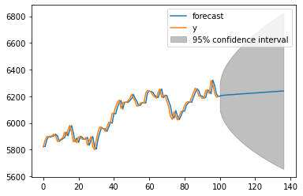

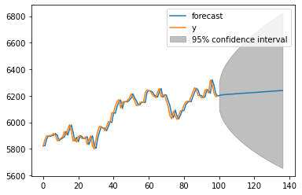

```python
model_arima_fit.plot_predict(2600,2736)
```

```python
predictions= model_arima_fit.forecast(steps=36)[0]
predictions[:10]
```

```
array([6201.47385639, 6205.02562644, 6207.18765189, 6208.65364076,
       6209.80986573, 6210.8345449 , 6211.80451548, 6212.75195451,
       6213.6901573 , 6214.62458248])
```

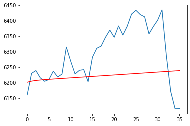

```python
plt.plot(test)
plt.plot(predictions,color='red')
```

# VECTOR AUTOREGRESSIVE MODEL

```python
#https://www.machinelearningplus.com/time-series/vector-autoregression-examples-python/
```

VAR model is a stochastic process that represents a group of time-dependent variables as a linear function of their own past values and the past values of all the other variables in the group.

Since the Y terms in the equations are interrelated, the Y’s are considered as endogenous variables, rather than as exogenous predictors

```python
from statsmodels.tsa.api import VAR
import statsmodels.api as sm
data = sm.datasets.macrodata.load_pandas().data
print(data.shape)
data.head(10)
```

```
(203, 14)
```

|  | year | quarter | realgdp | realcons | realinv | realgovt | realdpi | cpi | m1 | tbilrate | unemp | pop | infl | realint |
| --- | --- | --- | --- | --- | --- | --- | --- | --- | --- | --- | --- | --- | --- | --- |
| 0 | 1959.0 | 1.0 | 2710.349 | 1707.4 | 286.898 | 470.045 | 1886.9 | 28.98 | 139.7 | 2.82 | 5.8 | 177.146 | 0.00 | 0.00 |
| 1 | 1959.0 | 2.0 | 2778.801 | 1733.7 | 310.859 | 481.301 | 1919.7 | 29.15 | 141.7 | 3.08 | 5.1 | 177.830 | 2.34 | 0.74 |
| 2 | 1959.0 | 3.0 | 2775.488 | 1751.8 | 289.226 | 491.260 | 1916.4 | 29.35 | 140.5 | 3.82 | 5.3 | 178.657 | 2.74 | 1.09 |
| 3 | 1959.0 | 4.0 | 2785.204 | 1753.7 | 299.356 | 484.052 | 1931.3 | 29.37 | 140.0 | 4.33 | 5.6 | 179.386 | 0.27 | 4.06 |
| 4 | 1960.0 | 1.0 | 2847.699 | 1770.5 | 331.722 | 462.199 | 1955.5 | 29.54 | 139.6 | 3.50 | 5.2 | 180.007 | 2.31 | 1.19 |
| 5 | 1960.0 | 2.0 | 2834.390 | 1792.9 | 298.152 | 460.400 | 1966.1 | 29.55 | 140.2 | 2.68 | 5.2 | 180.671 | 0.14 | 2.55 |
| 6 | 1960.0 | 3.0 | 2839.022 | 1785.8 | 296.375 | 474.676 | 1967.8 | 29.75 | 140.9 | 2.36 | 5.6 | 181.528 | 2.70 | -0.34 |
| 7 | 1960.0 | 4.0 | 2802.616 | 1788.2 | 259.764 | 476.434 | 1966.6 | 29.84 | 141.1 | 2.29 | 6.3 | 182.287 | 1.21 | 1.08 |
| 8 | 1961.0 | 1.0 | 2819.264 | 1787.7 | 266.405 | 475.854 | 1984.5 | 29.81 | 142.1 | 2.37 | 6.8 | 182.992 | -0.40 | 2.77 |
| 9 | 1961.0 | 2.0 | 2872.005 | 1814.3 | 286.246 | 480.328 | 2014.4 | 29.92 | 142.9 | 2.29 | 7.0 | 183.691 | 1.47 | 0.81 |

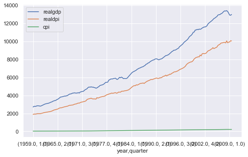

```python
data1 = data[["year","quarter","realgdp", "realdpi", "cpi"]]
data1 = data1.set_index(["year","quarter"])
data1.plot(figsize = (8,5))
```

```python
data_d = data1.diff().dropna()
print(data_d.shape)
data_d
```

```
(202, 3)
```

| year | quarter | realgdp | realdpi | cpi |
| --- | --- | --- | --- | --- |
| 1959.0 | 2.0 | 68.452 | 32.8 | 0.170 |
|  | 3.0 | -3.313 | -3.3 | 0.200 |
|  | 4.0 | 9.716 | 14.9 | 0.020 |
| 1960.0 | 1.0 | 62.495 | 24.2 | 0.170 |
|  | 2.0 | -13.309 | 10.6 | 0.010 |
| ... | ... | ... | ... | ... |
| 2008.0 | 3.0 | -90.666 | -220.7 | -1.721 |
|  | 4.0 | -182.680 | 82.1 | -4.715 |
| 2009.0 | 1.0 | -216.510 | 6.0 | 0.497 |
|  | 2.0 | -23.906 | 151.1 | 1.798 |
|  | 3.0 | 88.837 | -36.9 | 1.916 |

202 rows × 3 columns

Before applying VAR, the return of time series variable should be stationary.

```python
from statsmodels.tsa.stattools import adfuller
adfuller_test = adfuller(data_d['realgdp'], autolag= "AIC")
print("REAL GDP")
print("ADF test statistic: {}".format(adfuller_test[0]))
print("p-value: {}".format(adfuller_test[1]))
print("-"*50)
adfuller_test = adfuller(data_d['realdpi'], autolag= "AIC")
print("REAL DPI")
print("ADF test statistic: {}".format(adfuller_test[0]))
print("p-value: {}".format(adfuller_test[1]))
adfuller_test = adfuller(data_d['cpi'], autolag= "AIC")
print("-"*50)
print("REAL CPI")
print("ADF test statistic: {}".format(adfuller_test[0]))
print("p-value: {}".format(adfuller_test[1]))
```

```
REAL GDP
ADF test statistic: -6.305695561658104
p-value: 3.327882187668259e-08
--------------------------------------------------
REAL DPI
ADF test statistic: -8.864893340673007
p-value: 1.4493606159108096e-14
--------------------------------------------------
REAL CPI
ADF test statistic: -2.795504413542954
p-value: 0.05891880557886128
```

```python
#train-test split
train = data_d.iloc[:-10,:]
test = data_d.iloc[-10:,:]
```

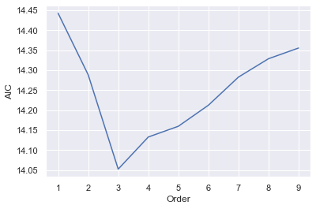

```python
#In the process of VAR modeling, we opt to employ Information Criterion Akaike (AIC) as a model selection criterion to conduct optimal model identification.
forecasting_model = VAR(train)
results_aic = []
for p in range(1,10):
  results = forecasting_model.fit(p)
  results_aic.append(results.aic)

import seaborn as sns
sns.set()
plt.plot(list(np.arange(1,10,1)), results_aic)
plt.xlabel("Order")
plt.ylabel("AIC")
plt.show()
```

```python
results = forecasting_model.fit(3)
results.summary()
```

```
  Summary of Regression Results
==================================
Model:                         VAR
Method:                        OLS
Date:           Tue, 24, Nov, 2020
Time:                     21:01:51
--------------------------------------------------------------------
No. of Equations:         3.00000    BIC:                    14.5672
Nobs:                     189.000    HQIC:                   14.2611
Log likelihood:          -2102.52    FPE:                1.26802e+06
AIC:                      14.0527    Det(Omega_mle):     1.08630e+06
--------------------------------------------------------------------
Results for equation realgdp
=============================================================================
                coefficient       std. error           t-stat            prob
-----------------------------------------------------------------------------
const             31.031344         8.658540            3.584           0.000
L1.realgdp         0.186831         0.081782            2.285           0.022
L1.realdpi         0.201818         0.086714            2.327           0.020
L1.cpi           -11.370717         6.500798           -1.749           0.080
L2.realgdp         0.226341         0.082905            2.730           0.006
L2.realdpi         0.017312         0.091011            0.190           0.849
L2.cpi            -1.030775         6.199382           -0.166           0.868
L3.realgdp         0.003477         0.079067            0.044           0.965
L3.realdpi         0.007158         0.088305            0.081           0.935
L3.cpi             3.268025         6.712406            0.487           0.626
=============================================================================

Results for equation realdpi
=============================================================================
                coefficient       std. error           t-stat            prob
-----------------------------------------------------------------------------
const             25.062514         7.730155            3.242           0.001
L1.realgdp         0.246741         0.073013            3.379           0.001
L1.realdpi        -0.203191         0.077417           -2.625           0.009
L1.cpi           -17.640651         5.803770           -3.040           0.002
L2.realgdp         0.067265         0.074016            0.909           0.363
L2.realdpi         0.050450         0.081253            0.621           0.535
L2.cpi            -0.478009         5.534673           -0.086           0.931
L3.realgdp         0.173851         0.070590            2.463           0.014
```

[output cut: 10 more lines]

```
L1.realdpi        -0.000072         0.000927           -0.078           0.938
L1.cpi             0.101500         0.069516            1.460           0.144
L2.realgdp        -0.000082         0.000887           -0.092           0.926
L2.realdpi        -0.000841         0.000973           -0.864           0.388
L2.cpi             0.255060         0.066293            3.847           0.000
L3.realgdp         0.000476         0.000846            0.563           0.574
L3.realdpi         0.001538         0.000944            1.629           0.103
L3.cpi             0.445426         0.071779            6.206           0.000
=============================================================================

Correlation matrix of residuals
            realgdp   realdpi       cpi
realgdp    1.000000  0.384528  0.146606
realdpi    0.384528  1.000000 -0.079719
cpi        0.146606 -0.079719  1.000000
```

```python
lagged_values = train.values[-3:]
forecast = pd.DataFrame(results.forecast(y= lagged_values, steps=10), index = test.index, columns= ['realgdp_1d', 'realdpi_1d', 'cpi'])
forecast
```

| year | quarter | realgdp_1d | realdpi_1d | cpi |
| --- | --- | --- | --- | --- |
| 2007.0 | 2.0 | 39.669648 | -19.817380 | 0.388108 |
|  | 3.0 | 43.910580 | 72.759611 | 1.712039 |
|  | 4.0 | 50.787519 | 37.707119 | 1.541381 |
| 2008.0 | 1.0 | 41.301482 | 23.691217 | 0.831843 |
|  | 2.0 | 50.898140 | 53.074036 | 1.464075 |
|  | 3.0 | 48.989095 | 37.965963 | 1.247500 |
|  | 4.0 | 47.622957 | 33.024815 | 1.016991 |
| 2009.0 | 1.0 | 50.831000 | 47.728786 | 1.280597 |
|  | 2.0 | 50.420796 | 37.561316 | 1.136649 |
|  | 3.0 | 49.844491 | 38.938757 | 1.065755 |

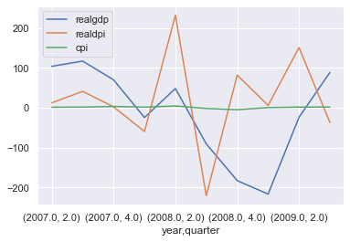

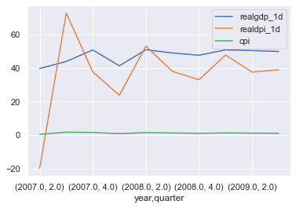

```python
test.plot()
forecast.plot()
```

# ERROR CORRECTION MODEL

https://towardsdatascience.com/vector-autoregressions-vector-error-correction-multivariate-model-a69daf6ab618

https://towardsdatascience.com/the-error-correction-model-for-co-integrated-time-series-and-checking-parameter-stability-a60bbdafb9e4

# PCA

PCA may be applied to any covariance or correlation matrix based on returs or P&L.  
Primary aims:

- reduce the number of risk factors
- identify the key source of risk
- facilitate the measurament of portofolio risk

### Review of Principal Components Analysis

Consider a set of n returns with time series data summarized in a T × n matrix X and let V be the covariance matrix (or correlation matrix) of X. The principal components of V are the columns of the T × n matrix P defined by $$ P = XW $$ where W is the n × n orthogonal matrix of eigenvectors of V. Since W is orthogonal, W−1 = W and so $$ X = PW' $$ A major aim of PCA is to use only a reduced set of principal components to represent the original variables X. For this purpose W is ordered so that the first column of W is the eigenvector corresponding to the largest eigenvalue of V, the second column of W is the eigenvector corresponding to the second eigenvalue of V, and so on. The mth principal component is the mth column of P, i.e. the column that is derived from the mth column of W. When we order the columns of W as above then the sum of squares of the elements in the mth principal component is the mth largest eigenvalue of V, denoted m. The total variation in X is the sum of the eigenvalues of V and the proportion of this total variation that is explained by the mth principal component is: $$ \frac{ λ_{M}}{ λ_{1} +...+ λ_{n}} $$ So between them the first k principal components of the returns capture a proportion $$ \frac{λ_{1} +...+ λ_{k}}{ λ_{1} +...+ λ_{n}} $$ Now we can choose k as follows. Either
• adjust k to capture a certain fixed proportion of the variation, such as 90% or 95%;
• set the number of principal components, such as k = 3 or k = 5, and then find how much of the variation is being captured by these components

### Case study: UK Government yield curves

```
              0.5 yr      1 yr    1.5 yr      2 yr    2.5 yr      3 yr  \
Date
2000-01-04  6.016259  6.320763  6.445353  6.478685  6.465539  6.427728
2000-01-05  6.011715  6.334398  6.465500  6.503121  6.495343  6.463951
2000-01-06  6.009169  6.325505  6.457042  6.498822  6.496094  6.469361
2000-01-07  5.979914  6.296293  6.419549  6.454178  6.447123  6.418117
2000-01-10  5.979279  6.276551  6.384266  6.409500  6.396607  6.363654

              3.5 yr      4 yr    4.5 yr      5 yr  ...   20.5 yr     21 yr  \
Date                                                ...
2000-01-04  6.376895  6.319470  6.258912  6.196902  ...  4.412237  4.389282
2000-01-05  6.420029  6.369541  6.315602  6.259662  ...  4.429173  4.404934
2000-01-06  6.429196  6.381403  6.329114  6.273890  ...  4.404146  4.377850
2000-01-07  6.376939  6.328860  6.276672  6.221728  ...  4.335837  4.307852
2000-01-10  6.319567  6.269182  6.215067  6.158463  ...  4.261183  4.232082

             21.5 yr     22 yr   22.5 yr     23 yr   23.5 yr     24 yr  \
Date
2000-01-04  4.368764  4.350558  4.334540  4.320596  4.308618  4.298504
2000-01-05  4.383356  4.364307  4.347654  4.333277  4.321059  4.310893
2000-01-06  4.354175  4.332992  4.314175  4.297606  4.283171  4.270766
2000-01-07  4.282521  4.259723  4.239340  4.221261  4.205377  4.191587
2000-01-10  4.205651  4.181781  4.160360  4.141283  4.124449  4.109759

             24.5 yr     25 yr
Date
2000-01-04  4.290159  4.283494
2000-01-05  4.302675  4.296309
2000-01-06  4.260291  4.251651
2000-01-07  4.179794  4.169903
2000-01-10  4.097118  4.086434

[5 rows x 50 columns]
```

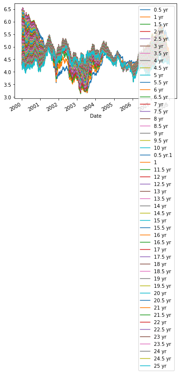

```python
df = pd.read_excel(path + 'II.2/Case Study II.2_PCA UK Yield Curves/PCA_Spot_Curve.xls', sheet_name = 'Spot').set_index('Date')
print(df.head())
df.plot()
```

```python
df.index=pd.to_datetime(df.index)

#period 1
start1 = datetime.datetime(2005, 1, 1, 0, 0)
end1 = datetime.datetime(2007, 12, 31, 0, 0)
df = df.loc[(df.index > start1) & (df.index < end1)]
```

```python
#calculate returns in basis points
df_ret_bp = (df.diff() *100 )[1:]
df_ret_bp.head()
```

| Date | 0.5 yr | 1 yr | 1.5 yr | 2 yr | 2.5 yr | 3 yr | 3.5 yr | 4 yr | 4.5 yr | 5 yr | ... | 20.5 yr | 21 yr | 21.5 yr | 22 yr | 22.5 yr | 23 yr | 23.5 yr | 24 yr | 24.5 yr | 25 yr |
| --- | --- | --- | --- | --- | --- | --- | --- | --- | --- | --- | --- | --- | --- | --- | --- | --- | --- | --- | --- | --- | --- |
| 2005-01-05 | 1.754403 | 0.928019 | 0.690246 | 0.593555 | 0.559177 | 0.567765 | 0.610057 | 0.678927 | 0.767888 | 0.870654 | ... | 1.593803 | 1.584633 | 1.576853 | 1.570430 | 1.565328 | 1.561501 | 1.558901 | 1.557475 | 1.557164 | 1.557912 |
| 2005-01-06 | 0.312350 | -1.243167 | -2.492377 | -3.202330 | -3.498446 | -3.538640 | -3.455924 | -3.330269 | -3.201794 | -3.089036 | ... | -3.859082 | -3.858607 | -3.855441 | -3.849867 | -3.842149 | -3.832528 | -3.821226 | -3.808450 | -3.794392 | -3.779223 |
| 2005-01-07 | 0.273331 | -0.095263 | 0.182239 | 0.347362 | 0.376852 | 0.326976 | 0.235986 | 0.125808 | 0.009119 | -0.106545 | ... | -1.156473 | -1.161420 | -1.164700 | -1.166273 | -1.166114 | -1.164208 | -1.160552 | -1.155152 | -1.148021 | -1.139180 |
| 2005-01-10 | -0.701902 | -0.889481 | -1.058286 | -1.112932 | -1.107631 | -1.078440 | -1.040836 | -1.000933 | -0.961100 | -0.922173 | ... | 1.049924 | 1.098749 | 1.144310 | 1.186729 | 1.226132 | 1.262645 | 1.296398 | 1.327522 | 1.356152 | 1.382417 |
| 2005-01-11 | 0.074072 | -0.489704 | -0.215808 | 0.093899 | 0.332822 | 0.505405 | 0.626933 | 0.710589 | 0.766303 | 0.801527 | ... | 1.946716 | 1.984688 | 2.020341 | 2.053762 | 2.085048 | 2.114308 | 2.141657 | 2.167222 | 2.191133 | 2.213521 |

5 rows × 50 columns

```python
#calculate stdev and its inverse
vol_ret = np.std(df_ret_bp) * np.sqrt(250)
inv_std_ret = 1/np.std(df_ret_bp)
```

```python
covMatrix = df_ret_bp.cov()
covMatrix
```

|  | 0.5 yr | 1 yr | 1.5 yr | 2 yr | 2.5 yr | 3 yr | 3.5 yr | 4 yr | 4.5 yr | 5 yr | ... | 20.5 yr | 21 yr | 21.5 yr | 22 yr | 22.5 yr | 23 yr | 23.5 yr | 24 yr | 24.5 yr | 25 yr |
| --- | --- | --- | --- | --- | --- | --- | --- | --- | --- | --- | --- | --- | --- | --- | --- | --- | --- | --- | --- | --- | --- |
| 0.5 yr | 4.358988 | 4.796265 | 4.837169 | 4.791921 | 4.706310 | 4.597629 | 4.475779 | 4.347519 | 4.217722 | 4.089984 | ... | 2.194210 | 2.158700 | 2.124336 | 2.091122 | 2.059058 | 2.028143 | 1.998370 | 1.969726 | 1.942196 | 1.915760 |
| 1 yr | 4.796265 | 6.925515 | 7.916365 | 8.280058 | 8.344369 | 8.266410 | 8.120168 | 7.942945 | 7.754816 | 7.567060 | ... | 4.560491 | 4.497256 | 4.435957 | 4.376598 | 4.319173 | 4.263671 | 4.210071 | 4.158346 | 4.108461 | 4.060377 |
| 1.5 yr | 4.837169 | 7.916365 | 9.718144 | 10.513594 | 10.782972 | 10.793674 | 10.676882 | 10.499144 | 10.295888 | 10.086579 | ... | 6.452748 | 6.371971 | 6.293621 | 6.217697 | 6.144186 | 6.073070 | 6.004318 | 5.937894 | 5.873753 | 5.811842 |
| 2 yr | 4.791921 | 8.280058 | 10.513594 | 11.568243 | 11.979857 | 12.068448 | 11.994469 | 11.840096 | 11.649269 | 11.446181 | ... | 7.586097 | 7.497108 | 7.410798 | 7.327159 | 7.246173 | 7.167813 | 7.092044 | 7.018820 | 6.948090 | 6.879798 |
| 2.5 yr | 4.706310 | 8.344369 | 10.782972 | 11.979857 | 12.483594 | 12.634270 | 12.604461 | 12.483118 | 12.318018 | 12.135577 | ... | 8.269522 | 8.177326 | 8.087945 | 8.001361 | 7.917550 | 7.836478 | 7.758101 | 7.682370 | 7.609228 | 7.538612 |
| 3 yr | 4.597629 | 8.266410 | 10.793674 | 12.068448 | 12.634270 | 12.835523 | 12.848149 | 12.763170 | 12.629619 | 12.474690 | ... | 8.716575 | 8.623648 | 8.533618 | 8.446460 | 8.362141 | 8.280619 | 8.201844 | 8.125759 | 8.052302 | 7.981407 |
| 3.5 yr | 4.475779 | 8.120168 | 10.676882 | 11.994469 | 12.604461 | 12.848149 | 12.900525 | 12.852280 | 12.752318 | 12.627802 | ... | 9.036585 | 8.944144 | 8.854660 | 8.768098 | 8.684418 | 8.603571 | 8.525497 | 8.450135 | 8.377416 | 8.307268 |
| 4 yr | 4.347519 | 7.942945 | 10.499144 | 11.840096 | 12.483118 | 12.763170 | 12.852280 | 12.839616 | 12.773243 | 12.679841 | ... | 9.284862 | 9.193489 | 9.105121 | 9.019717 | 8.937229 | 8.857598 | 8.780761 | 8.706646 | 8.635181 | 8.566286 |
| 4.5 yr | 4.217722 | 7.754816 | 10.295888 | 11.649269 | 12.318018 | 12.629619 | 12.752318 | 12.773243 | 12.739277 | 12.676385 | ... | 9.489943 | 9.399887 | 9.312881 | 9.228876 | 9.147817 | 9.069640 | 8.994273 | 8.921638 | 8.851655 | 8.784239 |
| 5 yr | 4.089984 | 7.567060 | 10.086579 | 11.446181 | 12.135577 | 12.474690 | 12.627802 | 12.679841 | 12.676385 | 12.642580 | ... | 9.666603 | 9.577940 | 9.492369 | 9.409835 | 9.330278 | 9.253626 | 9.179801 | 9.108719 | 9.040292 | 8.974430 |
| 5.5 yr | 3.966930 | 7.386103 | 9.881979 | 11.244231 | 11.950507 | 12.313595 | 12.493959 | 12.574368 | 12.599087 | 12.592425 | ... | 9.822312 | 9.735029 | 9.650877 | 9.569799 | 9.491728 | 9.416587 | 9.344291 | 9.274750 | 9.207871 | 9.143555 |
| 6 yr | 3.850337 | 7.215448 | 9.687790 | 11.050582 | 11.770764 | 12.154642 | 12.359158 | 12.465061 | 12.515375 | 12.533591 | ... | 9.960622 | 9.874666 | 9.791879 | 9.712202 | 9.635560 | 9.561873 | 9.491051 | 9.422997 | 9.357613 | 9.294793 |
| 6.5 yr | 3.741241 | 7.056667 | 9.506569 | 10.868568 | 11.600181 | 12.001939 | 12.227616 | 12.356127 | 12.429349 | 12.470012 | ... | 10.083031 | 9.998340 | 9.916854 | 9.838509 | 9.763227 | 9.690924 | 9.621505 | 9.554867 | 9.490907 | 9.429515 |
| 7 yr | 3.640050 | 6.910048 | 9.338905 | 10.699172 | 11.440077 | 11.857047 | 12.101047 | 12.249350 | 12.342800 | 12.403432 | ... | 10.190068 | 10.106590 | 10.026348 | 9.949273 | 9.875287 | 9.804300 | 9.736214 | 9.670922 | 9.608315 | 9.548277 |
| 7.5 yr | 3.546670 | 6.775015 | 9.184138 | 10.541904 | 11.290201 | 11.719948 | 11.979621 | 12.145040 | 12.256129 | 12.334296 | ... | 10.281883 | 10.199588 | 10.120551 | 10.044704 | 9.971964 | 9.902239 | 9.835428 | 9.771421 | 9.710103 | 9.651356 |
| 8 yr | 3.460668 | 6.650473 | 9.040899 | 10.395441 | 11.149412 | 11.589720 | 11.862631 | 12.042676 | 12.168961 | 12.262340 | ... | 10.358571 | 10.277455 | 10.199611 | 10.124970 | 10.053448 | 9.984952 | 9.919376 | 9.856608 | 9.796530 | 9.739021 |
| 8.5 yr | 3.381384 | 6.535045 | 8.907446 | 10.258023 | 11.016104 | 11.464970 | 11.748908 | 11.941299 | 12.080526 | 12.186952 | ... | 10.420319 | 10.340406 | 10.263769 | 10.190338 | 10.120031 | 10.052750 | 9.988389 | 9.926834 | 9.867964 | 9.811654 |
| 9 yr | 3.308039 | 6.427252 | 8.781932 | 10.127765 | 10.888522 | 11.344151 | 11.637135 | 11.839820 | 11.989945 | 12.107437 | ... | 10.467509 | 10.388850 | 10.313460 | 10.241270 | 10.172195 | 10.106139 | 10.042994 | 9.982643 | 9.924965 | 9.869831 |
| 9.5 yr | 3.239806 | 6.325648 | 8.662580 | 10.002857 | 10.764985 | 11.225780 | 11.526058 | 11.737218 | 11.896416 | 12.023194 | ... | 10.500766 | 10.423436 | 10.349355 | 10.278456 | 10.210653 | 10.145850 | 10.083937 | 10.024799 | 9.968310 | 9.914344 |
| 10 yr | 3.175879 | 6.228911 | 8.547813 | 9.881710 | 10.644028 | 11.108589 | 11.414630 | 11.632671 | 11.799339 | 11.933831 | ... | 10.520963 | 10.445055 | 10.372364 | 10.302823 | 10.236348 | 10.172841 | 10.112193 | 10.054287 | 9.999000 | 9.946203 |
| 0.5 yr.1 | 3.115507 | 6.135906 | 8.436320 | 9.763036 | 10.524498 | 10.991613 | 11.302099 | 11.525649 | 11.698400 | 11.839237 | ... | 10.529216 | 10.454837 | 10.383630 | 10.315527 | 10.250446 | 10.188289 | 10.128948 | 10.072307 | 10.018241 | 9.966623 |
| 1 | 3.058019 | 6.045686 | 8.327064 | 9.645855 | 10.405558 | 10.874199 | 11.188021 | 11.415921 | 11.593577 | 11.739591 | ... | 10.526848 | 10.454112 | 10.384489 | 10.317912 | 10.254299 | 10.193553 | 10.135568 | 10.080227 | 10.027408 | 9.976983 |
| 11.5 yr | 3.002839 | 5.957516 | 8.219290 | 9.529493 | 10.286674 | 10.755991 | 11.072231 | 11.303519 | 11.485099 | 11.635311 | ... | 10.515292 | 10.444316 | 10.376380 | 10.311419 | 10.249350 | 10.190081 | 10.133503 | 10.079502 | 10.027958 | 9.978743 |
| 12 yr | 2.949511 | 5.870861 | 8.112488 | 9.413535 | 10.167568 | 10.636870 | 10.954781 | 11.188675 | 11.373373 | 11.526974 | ... | 10.495985 | 10.426883 | 10.360736 | 10.297479 | 10.237033 | 10.179303 | 10.124185 | 10.071565 | 10.021324 | 9.973338 |
| 12.5 yr | 2.897680 | 5.785355 | 8.006351 | 9.297770 | 10.048155 | 10.516893 | 10.835884 | 11.071756 | 11.258925 | 11.415259 | ... | 10.470304 | 10.403183 | 10.338921 | 10.277454 | 10.218703 | 10.162575 | 10.108966 | 10.057766 | 10.008858 | 9.962119 |
| 13 yr | 2.847076 | 5.700758 | 7.900715 | 9.182134 | 9.928483 | 10.396237 | 10.715848 | 10.953208 | 11.142336 | 11.300880 | ... | 10.439518 | 10.374477 | 10.312189 | 10.252590 | 10.195602 | 10.141133 | 10.089081 | 10.039337 | 9.991787 | 9.946313 |
| 13.5 yr | 2.797495 | 5.616926 | 7.795521 | 9.066660 | 9.808691 | 10.275149 | 10.595039 | 10.833517 | 11.024214 | 11.184563 | ... | 10.404791 | 10.341917 | 10.281682 | 10.224020 | 10.168855 | 10.116096 | 10.065642 | 10.017388 | 9.971221 | 9.927027 |
| 14 yr | 2.748800 | 5.533811 | 7.690820 | 8.951491 | 9.689011 | 10.153960 | 10.473887 | 10.713217 | 10.905196 | 11.067049 | ... | 10.367188 | 10.306555 | 10.248439 | 10.192774 | 10.139484 | 10.088478 | 10.039659 | 9.992922 | 9.948158 | 9.905256 |
| 14.5 yr | 2.700918 | 5.451449 | 7.586754 | 8.836854 | 9.569752 | 10.033058 | 10.352865 | 10.592866 | 10.785926 | 10.949067 | ... | 10.327662 | 10.269329 | 10.213385 | 10.159765 | 10.108391 | 10.059174 | 10.012018 | 9.966821 | 9.923476 | 9.881876 |
| 15 yr | 2.653815 | 5.369922 | 7.483504 | 8.723007 | 9.451240 | 9.912839 | 10.232436 | 10.472997 | 10.667007 | 10.831290 | ... | 10.287022 | 10.231033 | 10.177302 | 10.125763 | 10.076337 | 10.028937 | 9.983466 | 9.939825 | 9.897912 | 9.857620 |
| 15.5 yr | 2.607488 | 5.289342 | 7.381276 | 8.610222 | 9.333803 | 9.793680 | 10.113033 | 10.354098 | 10.548985 | 10.714323 | ... | 10.245929 | 10.192314 | 10.140824 | 10.091391 | 10.043935 | 9.998369 | 9.954599 | 9.912528 | 9.872054 | 9.833076 |
| 16 yr | 2.561956 | 5.209830 | 7.280268 | 8.498751 | 9.217737 | 9.675923 | 9.995037 | 10.236592 | 10.432326 | 10.598672 | ... | 10.204892 | 10.153665 | 10.104431 | 10.057117 | 10.011644 | 9.967925 | 9.925865 | 9.885370 | 9.846341 | 9.808682 |
| 16.5 yr | 2.517245 | 5.131502 | 7.180663 | 8.388819 | 9.103298 | 9.559852 | 9.878764 | 10.120827 | 10.317408 | 10.484751 | ... | 10.164285 | 10.115450 | 10.068474 | 10.023284 | 9.979799 | 9.937929 | 9.897584 | 9.858669 | 9.821090 | 9.784750 |
| 17 yr | 2.473394 | 5.054474 | 7.082632 | 8.280631 | 8.990717 | 9.445719 | 9.764485 | 10.007096 | 10.204550 | 10.372902 | ... | 10.124391 | 10.077938 | 10.033214 | 9.990142 | 9.948640 | 9.908620 | 9.869988 | 9.832654 | 9.796525 | 9.761509 |
| 17.5 yr | 2.430446 | 4.978861 | 6.986341 | 8.174380 | 8.880204 | 9.333749 | 9.652443 | 9.895657 | 10.094026 | 10.263415 | ... | 10.085422 | 10.041331 | 9.998841 | 9.957873 | 9.918345 | 9.880165 | 9.843243 | 9.807488 | 9.772810 | 9.739120 |
| 18 yr | 2.388453 | 4.904781 | 6.891952 | 8.070251 | 8.771956 | 9.224149 | 9.542852 | 9.786735 | 9.986071 | 10.156539 | ... | 10.047533 | 10.005772 | 9.965490 | 9.926605 | 9.889033 | 9.852682 | 9.817462 | 9.783282 | 9.750055 | 9.717696 |
| 18.5 yr | 2.347459 | 4.832337 | 6.799608 | 7.968405 | 8.666144 | 9.117094 | 9.435892 | 9.680514 | 9.880877 | 10.052475 | ... | 10.010821 | 9.971350 | 9.933241 | 9.896412 | 9.860773 | 9.826234 | 9.792705 | 9.760096 | 9.728321 | 9.697298 |
| 19 yr | 2.307507 | 4.761621 | 6.709430 | 7.868976 | 8.562905 | 9.012722 | 9.331701 | 9.577134 | 9.778586 | 9.951368 | ... | 9.975332 | 9.938102 | 9.902126 | 9.867317 | 9.833585 | 9.800839 | 9.768987 | 9.737943 | 9.707621 | 9.677943 |
| 19.5 yr | 2.268632 | 4.692707 | 6.621517 | 7.772069 | 8.462344 | 8.911137 | 9.230382 | 9.476697 | 9.679300 | 9.853322 | ... | 9.941070 | 9.906025 | 9.872134 | 9.839307 | 9.807451 | 9.776474 | 9.746287 | 9.716802 | 9.687936 | 9.659613 |
| 20 yr | 2.230859 | 4.625650 | 6.535939 | 7.677759 | 8.364535 | 8.812409 | 9.131999 | 9.379264 | 9.583078 | 9.758393 | ... | 9.908002 | 9.875083 | 9.843224 | 9.812334 | 9.782321 | 9.753090 | 9.724553 | 9.696622 | 9.669217 | 9.642263 |
| 20.5 yr | 2.194210 | 4.560491 | 6.452748 | 7.586097 | 8.269522 | 8.716575 | 9.036585 | 9.284862 | 9.489943 | 9.666603 | ... | 9.876075 | 9.845214 | 9.815331 | 9.786334 | 9.758127 | 9.730618 | 9.703715 | 9.677336 | 9.651399 | 9.625832 |
| 21 yr | 2.158700 | 4.497256 | 6.371971 | 7.497108 | 8.177326 | 8.623648 | 8.944144 | 9.193489 | 9.399887 | 9.577940 | ... | 9.845214 | 9.816342 | 9.788377 | 9.761223 | 9.734787 | 9.708973 | 9.683693 | 9.658863 | 9.634405 | 9.610248 |
| 21.5 yr | 2.124336 | 4.435957 | 6.293621 | 7.410798 | 8.087945 | 8.533618 | 8.854660 | 9.105121 | 9.312881 | 9.492369 | ... | 9.815331 | 9.788377 | 9.762269 | 9.736910 | 9.712207 | 9.688064 | 9.664395 | 9.641116 | 9.618150 | 9.595429 |
| 22 yr | 2.091122 | 4.376598 | 6.217697 | 7.327159 | 8.001361 | 8.446460 | 8.768098 | 9.019717 | 9.228876 | 9.409835 | ... | 9.786334 | 9.761223 | 9.736910 | 9.713297 | 9.690290 | 9.667797 | 9.645728 | 9.624004 | 9.602549 | 9.581296 |
| 22.5 yr | 2.059058 | 4.319173 | 6.144186 | 7.246173 | 7.917550 | 8.362141 | 8.684418 | 8.937229 | 9.147817 | 9.330278 | ... | 9.758127 | 9.734787 | 9.712207 | 9.690290 | 9.668944 | 9.648077 | 9.627603 | 9.607441 | 9.587520 | 9.567772 |
| 23 yr | 2.028143 | 4.263671 | 6.073070 | 7.167813 | 7.836478 | 8.280619 | 8.603571 | 8.857598 | 9.069640 | 9.253626 | ... | 9.730618 | 9.708973 | 9.688064 | 9.667797 | 9.648077 | 9.628818 | 9.609932 | 9.591344 | 9.572982 | 9.554781 |
| 23.5 yr | 1.998370 | 4.210071 | 6.004318 | 7.092044 | 7.758101 | 8.201844 | 8.525497 | 8.780761 | 8.994273 | 9.179801 | ... | 9.703715 | 9.683693 | 9.664395 | 9.645728 | 9.627603 | 9.609932 | 9.592634 | 9.575633 | 9.558860 | 9.542252 |
| 24 yr | 1.969726 | 4.158346 | 5.937894 | 7.018820 | 7.682370 | 8.125759 | 8.450135 | 8.706646 | 8.921638 | 9.108719 | ... | 9.677336 | 9.658863 | 9.641116 | 9.624004 | 9.607441 | 9.591344 | 9.575633 | 9.560235 | 9.545084 | 9.530118 |
| 24.5 yr | 1.942196 | 4.108461 | 5.873753 | 6.948090 | 7.609228 | 8.052302 | 8.377416 | 8.635181 | 8.851655 | 9.040292 | ... | 9.651399 | 9.634405 | 9.618150 | 9.602549 | 9.587520 | 9.572982 | 9.558860 | 9.545084 | 9.531589 | 9.518318 |
| 25 yr | 1.915760 | 4.060377 | 5.811842 | 6.879798 | 7.538612 | 7.981407 | 8.307268 | 8.566286 | 8.784239 | 8.974430 | ... | 9.625832 | 9.610248 | 9.595429 | 9.581296 | 9.567772 | 9.554781 | 9.542252 | 9.530118 | 9.518318 | 9.506796 |

50 rows × 50 columns

Performing principal component analysis decomposes the matrix C into:

$$ C=LPL⊤ $$

where P is a diagonal matrix $ P=diag(λ1,λ2,…,λm) $, with $ λ1≥λ1≥…λm≥0 $ being the eigenvalues of matrix C . The matrix L is an orthogonal matrix, consisting the eigenvectors of matrix C .

```python
from numpy import linalg as LA
enval, envec = LA.eigh(covMatrix)
```

```python
#a[::-1], it starts from the end towards the first taking each element. So it reverses a
enval = enval[::-1]
print(enval)
envec = envec[:,::-1]
envec
```

```
[5.08609433e+02 3.39924519e+01 5.01686532e+00 2.52775447e+00
 5.64313852e-01 1.73754214e-01 5.92662803e-02 1.76843777e-02
 3.40611436e-03 8.74786399e-04 1.43704961e-04 3.42698161e-05
 9.29307440e-06 2.42339166e-06 9.18125929e-07 3.30417696e-07
 1.09683592e-07 6.75340086e-08 3.22897098e-08 1.54224018e-08
 1.04724574e-08 7.40021665e-09 3.17154785e-09 1.39881432e-09
 8.14943837e-10 3.67487800e-10 2.73667025e-10 2.22466825e-10
 1.42091891e-10 1.12756363e-10 9.15368225e-11 3.92981545e-11
 3.34434730e-11 2.39402374e-11 2.00049443e-11 9.31085776e-12
 8.41964671e-12 6.34058538e-12 2.96112002e-12 1.16670079e-12
 7.83017328e-13 7.75366598e-13 3.25714337e-13 3.21194142e-13
 2.97952000e-13 1.43904396e-13 3.97767384e-14 2.98082399e-14
 1.46643286e-14 1.07724129e-14]
```

```
array([[ 4.21651789e-02, -2.00969188e-01,  4.25052287e-01, ...,
         0.00000000e+00,  0.00000000e+00,  0.00000000e+00],
       [ 8.13668237e-02, -2.76723976e-01,  3.55359594e-01, ...,
         2.14642640e-07, -3.46916856e-09, -2.10207387e-08],
       [ 1.10887206e-01, -3.01823469e-01,  2.37865964e-01, ...,
        -2.08576176e-06, -3.25805186e-07,  6.05923774e-08],
       ...,
       [ 1.29718673e-01,  1.53827978e-01,  1.79317580e-01, ...,
        -2.21196189e-01,  6.14018537e-02,  2.06691298e-01],
       [ 1.29082915e-01,  1.57227176e-01,  1.85713759e-01, ...,
         1.03605989e-01, -9.89099344e-03, -8.68887144e-02],
       [ 1.28470210e-01,  1.60477251e-01,  1.91517993e-01, ...,
        -2.02540353e-02, -2.18011615e-04,  1.59160556e-02]])
```

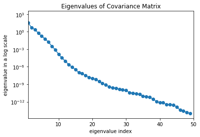

```python
#plot eingenvalues
plt.semilogy(enval, '-o')
plt.xlim([1, enval.shape[0]])
plt.xlabel('eigenvalue index')
plt.ylabel('eigenvalue in a log scale')
plt.title('Eigenvalues of Covariance Matrix');
```

```python
(enval/enval.sum()).sum()
```

```
1.0
```

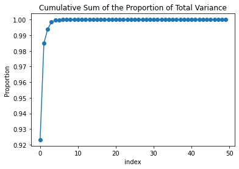

```python
plt.plot((enval/enval.sum()).cumsum(), '-o')
plt.title('Cumulative Sum of the Proportion of Total Variance')
plt.xlabel('index')
plt.ylabel('Proportion');
```

```python
from sklearn.decomposition import PCA
num_pc = 3

X = np.asarray(df_ret_bp)
[n,m] = X.shape
print ('The number of timestamps is {}.'.format(n))
print ('The number of stocks is {}.'.format(m))

pca = PCA(n_components=num_pc) # number of principal components
pca.fit(X)

percentage =  pca.explained_variance_ratio_
percentage_cum = np.cumsum(percentage)
print ('{0:.2f}% of the variance is explained by the first 2 PCs'.format(percentage_cum[-1]*100))

pca_components = pca.components_
```

[output not shown]

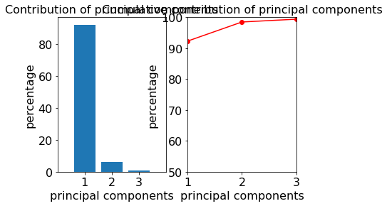

```python
x = np.arange(1,len(percentage)+1,1)

plt.subplot(1, 2, 1)
plt.bar(x, percentage*100, align = "center")
plt.title('Contribution of principal components',fontsize = 16)
plt.xlabel('principal components',fontsize = 16)
plt.ylabel('percentage',fontsize = 16)
plt.xticks(x,fontsize = 16)
plt.yticks(fontsize = 16)
plt.xlim([0, num_pc+1])

plt.subplot(1, 2, 2)
plt.plot(x, percentage_cum*100,'ro-')
plt.xlabel('principal components',fontsize = 16)
plt.ylabel('percentage',fontsize = 16)
plt.title('Cumulative contribution of principal components',fontsize = 16)
plt.xticks(x,fontsize = 16)
plt.yticks(fontsize = 16)
plt.xlim([1, num_pc])
plt.ylim([50,100]);
```

```python
factor_returns = X.dot(pca_components.T)
factor_returns = pd.DataFrame(columns=["factor 1", "factor 2",  "factor 3"],
                              index=df_ret_bp.index,
                              data=factor_returns)
factor_returns.head()
```

| Date | factor 1 | factor 2 | factor 3 |
| --- | --- | --- | --- |
| 2005-01-05 | 10.216356 | -2.052373 | 0.723839 |
| 2005-01-06 | -23.632277 | 2.417260 | -1.962392 |
| 2005-01-07 | -5.114457 | 3.362505 | -0.395558 |
| 2005-01-10 | 0.151237 | -5.439667 | 2.386651 |
| 2005-01-11 | 8.641582 | -4.081182 | 1.662905 |

# ARCH and GARCH

The moving average models are based on the assumption that returns are independent and identically distributed (i.i.d.). But we know that the i.i.d. assumption is very unrealistic. The volatility of financial asset returns changes over time, with periods when volatility is exceptionally high interspersed with periods when volatility is unusually low. This volatility clustering behaviour does, of course, depend on the frequency of the data.  
The generalized autoregressive conditional heteroscedasticity (GARCH) models of volatility that were introduced by Engle (1982) and Bollerslev (1986) are specifically designed to capture the volatility clustering of returns. The forecasts that are made from these models are not equal to the current estimate. Instead volatility can be higher or lower than average over the short term but as the forecast horizon increases the GARCH volatility forecasts converge to the long term volatility.  
• the approach is autoregressive because GARCH is a time series model with an autoregressive (regression on itself) form;  
• and we speak of conditional heteroscedasticity because time variation in conditional variance is built into the model. The unconditional variance is just the variance of the unconditional returns distribution, which is assumed constant over the entire data period considered. It can be thought of as the long term average variance over that period.  
The conditional variance, on the other hand, will change at every point in time because it depends on the history of returns up to that point. That is, we account for the dynamic properties of returns by regarding their distribution at any point in time as being conditional on all the information up to that point. We denote the information set, which is the set containing all the past returns up to and including time t − 1, by It−1.

### THE SYMMETRIC NORMAL GARCH MODEL

It assumes that the dynamic behaviour of the conditional variance is given by the following conditional variance equation: $$ σ_{t}^2 = w + αε_{t-1}^2 + Bσ_{t-1}^2 \quad ε_{t}, I_{t-1} \sim N(0 , σ_{t}^2) $$ The GARCH conditional volatility is defined as the annualized square root of this conditional variance. The conditional variance and volatility are conditional on the information set. Since the conditional variances at different points in time are related the process is not identically distributed and neither is it independent at different points in time are related.

LONG TERM VOLATILITY:
The long term or unconditional variance is: $$ \barσ_{t}^2 = \frac{w}{1 - (α + B)} $$

INTERPRETATION:  
• The GARCH error parameter $\textbf α $ measures the reaction of conditional volatility to market shocks. When α is relatively large (e.g. above 0.1) then volatility is very sensitive to market events.  
• The GARCH lag parameter $\textbf β $ measures the persistence in conditional volatility irrespective of anything happening in the market. When β is relatively large (e.g. above 0.9) then volatility takes a long time to die out following a crisis in the market.  
• The sum $ \textbf α + β $ determines the rate of convergence of the conditional volatility to the long term average level. When α + β is relatively large (e.g. above 0.99) then the terms structure of volatility forecasts from the GARCH model is relatively flat.  
• The GARCH constant parameter $ \textbf w $, together with the sum α + β, determines the level of the long term average volatility, i.e. the unconditional volatility in the GARCH model.

```python
def simulate_GARCH(T, a0, a1, b1, sigma1):

    # Initialize our values
    X = np.ndarray(T)
    sigma = np.ndarray(T)
    sigma[0] = sigma1

    for t in range(1, T):
        # Draw the next x_t
        X[t - 1] = sigma[t - 1] * np.random.normal(0, 1)
        # Draw the next sigma_t
        sigma[t] = math.sqrt(a0 + b1 * sigma[t - 1]**2 + a1 * X[t - 1]**2)

    X[T - 1] = sigma[T - 1] * np.random.normal(0, 1)

    return X, sigma
```

```python
#example
# Define parameters
w = 1.0
a = 0.01
b = 0.8
sigma1 = math.sqrt(w / (1 - a - b)) # unconditional variance
X, cond_sigma = simulate_GARCH(100, w, a, b, sigma1)
```

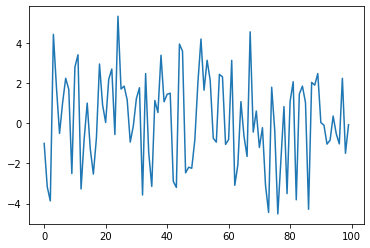

```python
plt.plot(X)
```

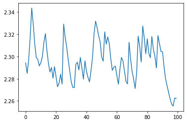

```python
plt.plot(cond_sigma)
```

# VALUE AT RISK

Value at risk (VaR) is a statistic used to try and quantify the level of financial risk within a firm or portfolio over a specified time frame. VaR provides an estimate of the maximum loss from a given position or portfolio over a period of time

We'll use historical VaR, which looks at previous returns distributions and uses that to compute the p percentile. This percentile is the amount of loss you could reasonably expect to experience with probability p , assuming future returns are close to past returns

```python
from pandas_datareader import data as pdr
import numpy as np
import datetime as dt

# Create our portfolio of equities
tickers = ['AAPL','FB', 'C', 'DIS']

# Download closing prices
data = pdr.get_data_yahoo(tickers, start="2018-01-01", end=dt.date.today())['Close']
data.head()
```

| Symbols Date | AAPL | FB | C | DIS |
| --- | --- | --- | --- | --- |
| 2018-01-02 | 43.064999 | 181.419998 | 74.360001 | 111.800003 |
| 2018-01-03 | 43.057499 | 184.669998 | 74.589996 | 112.279999 |
| 2018-01-04 | 43.257500 | 184.330002 | 75.510002 | 112.230003 |
| 2018-01-05 | 43.750000 | 186.850006 | 75.410004 | 111.620003 |
| 2018-01-08 | 43.587502 | 188.279999 | 74.529999 | 110.019997 |

```python
#From the closing prices, calculate periodic returns
returns = data.pct_change()[1:]
returns.head()
```

| Symbols Date | AAPL | FB | C | DIS |
| --- | --- | --- | --- | --- |
| 2018-01-03 | -0.000174 | 0.017914 | 0.003093 | 0.004293 |
| 2018-01-04 | 0.004645 | -0.001841 | 0.012334 | -0.000445 |
| 2018-01-05 | 0.011385 | 0.013671 | -0.001324 | -0.005435 |
| 2018-01-08 | -0.003714 | 0.007653 | -0.011670 | -0.014334 |
| 2018-01-09 | -0.000115 | -0.002178 | 0.010466 | -0.000727 |

### Historical

```python
# Set the investment weights (I arbitrarily picked for example)
weights = np.array([.25, .3, .15, .3])
#lookback_days
lookback_days = 250
alpha = 0.95
value_invested = 10000

#calculate portfolio returns
portfolio_retutns = returns.dot(weights) * value_invested
portfolio_retutns.head()
```

```
Date
2018-01-03    70.826859
2018-01-04    23.254550
2018-01-05    51.184481
2018-01-08   -46.833767
2018-01-09     6.697366
dtype: float64
```

```python
portfolio_retutns_var = portfolio_retutns.iloc[-lookback_days:]
print("Historical VAR calculated on "+ str(lookback_days) + " days with " + str(alpha) + " confidence level")
portfolio_VaR_return = np.percentile(portfolio_retutns_var, 100 * (1-alpha))
portfolio_VaR_return
```

```
Historical VAR calculated on 250 days with 0.95 confidence level
```

```
-403.41839057028255
```

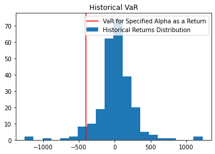

```python
plt.hist(portfolio_retutns_var, bins=20)
plt.axvline(portfolio_VaR_return, color='red', linestyle='solid');
plt.legend(['VaR for Specified Alpha as a Return', 'Historical Returns Distribution'])
plt.title('Historical VaR');
```

no more than 5% of days resulted in losses more extreme than this, or that on each day your probability of losing this much is less than 5%

### Parametric

you assume that the returns follow a given distribution rather than non-parametrically estiamting it historically. We can check this by using a normal distribution Cumulative Distribution Function (CDF), which sums the area under a normal curve to figure out how likely certain values are. $$ VAR_{α} = u - σN^{-1}(α) $$

```python
mu = portfolio_retutns.mean()
covar = returns.cov()
portfolio_std = np.dot(weights.T,np.dot(covar,weights))

# manually
(mu - portfolio_std * norm.ppf(0.95)) * value_invested
```

```
84700.09635040544
```

```python
np.dot(weights.T,np.dot(covar,weights))
```

```
0.0003490660756980161
```

### Montecarlo Simulation

The Monte Carlo simulation is a probability model which generates random variables used in tandem with economic factors (expected return, volatility — in the case of a portfolio of funds) to predict outcomes over a large spectrum.

```python
np.random.seed(40)
n_sims = 1000000
sim_returns = np.random.normal(mu, portfolio_std, n_sims)
SimVAR = portfolio_retutns[-1]*np.percentile(sim_returns, 1)
print('Simulated VAR is ', SimVAR)
```

```
Simulated VAR is  -366.4759297973498
```

```python
sim_returns
```

```
array([8.47037172, 8.47053977, 8.47034482, ..., 8.47057672, 8.47107423,
       8.47061462])
```